# Data handling and curation - from raw to clean data

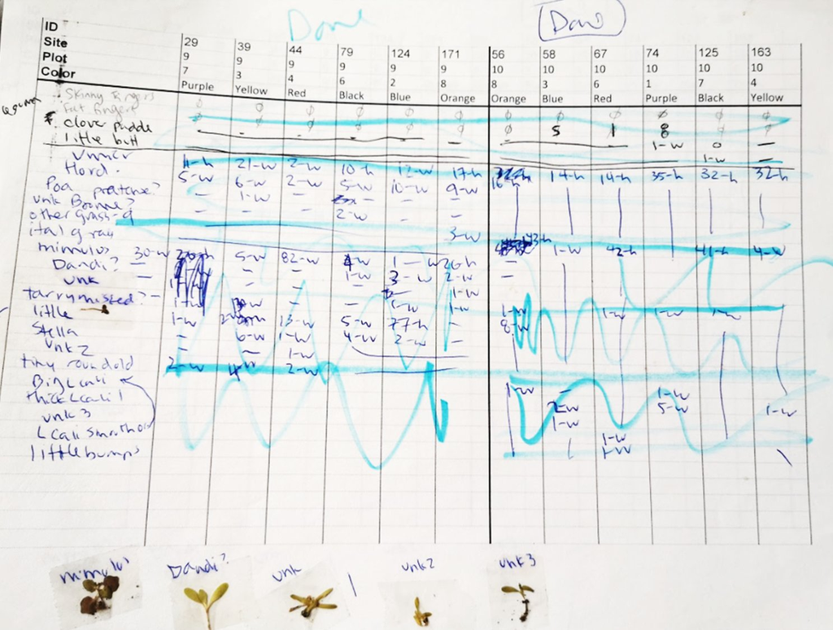

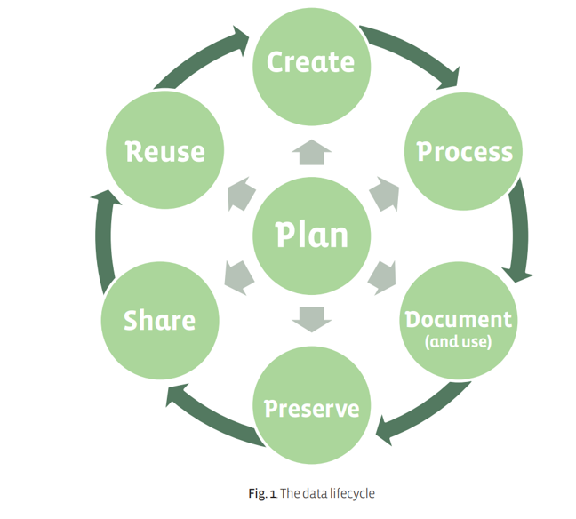

## Data handling & curation

Managing the “data life-cycle” within and beyond a project.

- creating data
- organising data
- maintaining data

## Data cleaning vs Data wrangling

*Data cleaning* is the process of removing incorrect, duplicate, or otherwise erroneous data from a dataset

*Data wrangling* changing the format to make it more useful for your analysis

## Some R Functions that help data cleaning

### {janitor}

```r
library(tidyverse)
library(palmerpenguins)
library(janitor)
palmerpenguins::penguins_raw |>  names()
```

```
 [1] "studyName"           "Sample Number"       "Species"
 [4] "Region"              "Island"              "Stage"
 [7] "Individual ID"       "Clutch Completion"   "Date Egg"
[10] "Culmen Length (mm)"  "Culmen Depth (mm)"   "Flipper Length (mm)"
[13] "Body Mass (g)"       "Sex"                 "Delta 15 N (o/oo)"
[16] "Delta 13 C (o/oo)"   "Comments"
```

```r
janitor::clean_names(palmerpenguins::penguins_raw) |>  names()
```

```
 [1] "study_name"        "sample_number"     "species"
 [4] "region"            "island"            "stage"
 [7] "individual_id"     "clutch_completion" "date_egg"
[10] "culmen_length_mm"  "culmen_depth_mm"   "flipper_length_mm"
[13] "body_mass_g"       "sex"               "delta_15_n_o_oo"
[16] "delta_13_c_o_oo"   "comments"
```

### {dplyr}

```r
clean_penguins<-janitor::clean_names(palmerpenguins::penguins_raw)

dplyr::glimpse(clean_penguins)
```

```
Rows: 344
Columns: 17
$ study_name        <chr> "PAL0708", "PAL0708", "PAL0708", "PAL0708", "PAL0708…
$ sample_number     <dbl> 1, 2, 3, 4, 5, 6, 7, 8, 9, 10, 11, 12, 13, 14, 15, 1…
$ species           <chr> "Adelie Penguin (Pygoscelis adeliae)", "Adelie Pengu…
$ region            <chr> "Anvers", "Anvers", "Anvers", "Anvers", "Anvers", "A…
$ island            <chr> "Torgersen", "Torgersen", "Torgersen", "Torgersen", …
$ stage             <chr> "Adult, 1 Egg Stage", "Adult, 1 Egg Stage", "Adult, …
$ individual_id     <chr> "N1A1", "N1A2", "N2A1", "N2A2", "N3A1", "N3A2", "N4A…
$ clutch_completion <chr> "Yes", "Yes", "Yes", "Yes", "Yes", "Yes", "No", "No"…
$ date_egg          <date> 2007-11-11, 2007-11-11, 2007-11-16, 2007-11-16, 200…
$ culmen_length_mm  <dbl> 39.1, 39.5, 40.3, NA, 36.7, 39.3, 38.9, 39.2, 34.1, …
$ culmen_depth_mm   <dbl> 18.7, 17.4, 18.0, NA, 19.3, 20.6, 17.8, 19.6, 18.1, …
$ flipper_length_mm <dbl> 181, 186, 195, NA, 193, 190, 181, 195, 193, 190, 186…
$ body_mass_g       <dbl> 3750, 3800, 3250, NA, 3450, 3650, 3625, 4675, 3475, …
$ sex               <chr> "MALE", "FEMALE", "FEMALE", NA, "FEMALE", "MALE", "F…
$ delta_15_n_o_oo   <dbl> NA, 8.94956, 8.36821, NA, 8.76651, 8.66496, 9.18718,…
$ delta_13_c_o_oo   <dbl> NA, -24.69454, -25.33302, NA, -25.32426, -25.29805, …
$ comments          <chr> "Not enough blood for isotopes.", NA, NA, "Adult not…
```

### {skimr}

```r
out<-skimr::skim(palmerpenguins::penguins_raw)

out
```

Data summary

| Name | palmerpenguins::penguins_… |
| --- | --- |
| Number of rows | 344 |
| Number of columns | 17 |
| _______________________ |  |
| Column type frequency: |  |
| character | 9 |
| Date | 1 |
| numeric | 7 |
| ________________________ |  |
| Group variables | None |

**Variable type: character**

| skim_variable | n_missing | complete_rate | min | max | empty | n_unique | whitespace |
| --- | --- | --- | --- | --- | --- | --- | --- |
| studyName | 0 | 1.00 | 7 | 7 | 0 | 3 | 0 |
| Species | 0 | 1.00 | 33 | 41 | 0 | 3 | 0 |
| Region | 0 | 1.00 | 6 | 6 | 0 | 1 | 0 |
| Island | 0 | 1.00 | 5 | 9 | 0 | 3 | 0 |
| Stage | 0 | 1.00 | 18 | 18 | 0 | 1 | 0 |
| Individual ID | 0 | 1.00 | 4 | 6 | 0 | 190 | 0 |
| Clutch Completion | 0 | 1.00 | 2 | 3 | 0 | 2 | 0 |
| Sex | 11 | 0.97 | 4 | 6 | 0 | 2 | 0 |
| Comments | 290 | 0.16 | 18 | 68 | 0 | 10 | 0 |

**Variable type: Date**

| skim_variable | n_missing | complete_rate | min | max | median | n_unique |
| --- | --- | --- | --- | --- | --- | --- |
| Date Egg | 0 | 1 | 2007-11-09 | 2009-12-01 | 2008-11-09 | 50 |

**Variable type: numeric**

| skim_variable | n_missing | complete_rate | mean | sd | p0 | p25 | p50 | p75 | p100 | hist |
| --- | --- | --- | --- | --- | --- | --- | --- | --- | --- | --- |
| Sample Number | 0 | 1.00 | 63.15 | 40.43 | 1.00 | 29.00 | 58.00 | 95.25 | 152.00 | ▇▇▆▅▃ |
| Culmen Length (mm) | 2 | 0.99 | 43.92 | 5.46 | 32.10 | 39.23 | 44.45 | 48.50 | 59.60 | ▃▇▇▆▁ |
| Culmen Depth (mm) | 2 | 0.99 | 17.15 | 1.97 | 13.10 | 15.60 | 17.30 | 18.70 | 21.50 | ▅▅▇▇▂ |
| Flipper Length (mm) | 2 | 0.99 | 200.92 | 14.06 | 172.00 | 190.00 | 197.00 | 213.00 | 231.00 | ▂▇▃▅▂ |
| Body Mass (g) | 2 | 0.99 | 4201.75 | 801.95 | 2700.00 | 3550.00 | 4050.00 | 4750.00 | 6300.00 | ▃▇▆▃▂ |
| Delta 15 N (o/oo) | 14 | 0.96 | 8.73 | 0.55 | 7.63 | 8.30 | 8.65 | 9.17 | 10.03 | ▃▇▆▅▂ |
| Delta 13 C (o/oo) | 13 | 0.96 | -25.69 | 0.79 | -27.02 | -26.32 | -25.83 | -25.06 | -23.79 | ▆▇▅▅▂ |

### {dplyr}

```r
#Deduplication
data<-tibble(Day=c("Monday", "Tuesday","Wednesday", "Wednesday"),
             Person=c("Becks", "Amy", "Matt", "Matt"))
data
```

```
# A tibble: 4 × 2
  Day       Person
  <chr>     <chr>
1 Monday    Becks
2 Tuesday   Amy
3 Wednesday Matt
4 Wednesday Matt
```

```r
data |> dplyr::distinct()
```

```
# A tibble: 3 × 2
  Day       Person
  <chr>     <chr>
1 Monday    Becks
2 Tuesday   Amy
3 Wednesday Matt
```

### {naniar}

```r
# creating some data with missing values
missing_penguins<-missMethods::delete_MCAR(clean_penguins, 0.3)


missing_penguins |>
naniar::vis_miss()
```

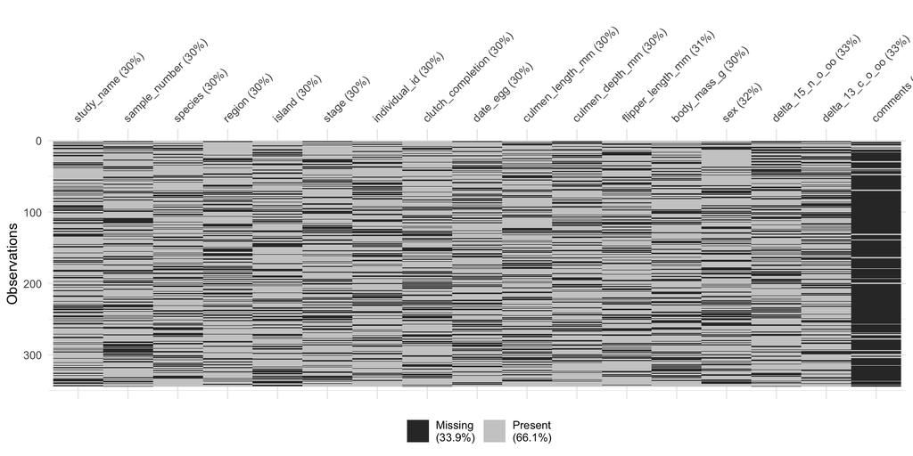

## Missing data

Missing data is normally a problem. Typically as ecologists we sweep missing data under the carpet by using a “complete case” approach to data analysis.

[figure not shown]

If you have ever written some code like this:

```r
# na.omit()
df <- na.omit(df)
# complete.cases()
df <- df[complete.cases(df), ]
# rowSums()
df <- df[rowSums(is.na(df)) == 0, ]
# drop_na()
df <- df  |>  tidyr::drop_na()
```

you are removing missing data (NAs) from your dataset.

## Why is this a problem?

By throwing away potentially useful data (only including those rows without a NA in them) you reduce the information you are working with, reduce statistical power and introduce selection bias (invalidating any assumption of randomisation).

## Different types of missingness

There are three broad categories of missing data:

- MCAR - missingness is not related to any measured or unmeasured variables
- MAR - missingness is not random but related to other variables and can be accounted for by another complete variable
- MNAR - missingness is related to the missing data itself (there is a systematic reason why the data are missing within a particular variable)

Imagine that we are measuring rainfall at weather stations across Norway every year.

Table 1: Missing data patterns - MCAR

(a) Complete data

| station number | rainfall |
| --- | --- |
| 1 | 30 |
| 2 | 150 |
| 3 | 75 |
| 4 | 250 |
| 5 | 55 |

(b) MCAR

| station number | rainfall |
| --- | --- |
| 1 | 30 |
| 2 |  |
| 3 |  |
| 4 | 250 |
| 5 | 55 |

Table 2: Complete data

| station number | rainfall |
| --- | --- |
| 1 | 30 |
| 2 | 150 |
| 3 | 75 |
| 4 | 250 |
| 5 | 55 |

Table 3: MAR

| station number | rainfall |
| --- | --- |
| 1 |  |
| 2 |  |
| 3 |  |
| 4 | 250 |
| 5 | 55 |

Missing data patterns - MAR

Table 4: Complete data

| station number | rainfall |
| --- | --- |
| 1 | 30 |
| 2 | 150 |
| 3 | 75 |
| 4 | 250 |
| 5 | 55 |

Table 5: MNAR

| station number | rainfall |
| --- | --- |
| 1 | 30 |
| 2 |  |
| 3 | 75 |
| 4 |  |
| 5 | 55 |

Missing data patterns - MNAR

## What effect does missingness have?

```r
library(tidyverse, quietly = TRUE)
library(missMethods, quietly = TRUE)
library(palmerpenguins)

#create datasets with levels missingness

penguins_complete<-penguins |>
  drop_na()

miss_penguins_MCAR<-
  missMethods::delete_MCAR(penguins_complete,
                                             0.3, "flipper_length_mm")
# create a pattern of missingness with censoring
#(missing value in flipper_length
#if body_mass is below 30% quantile of body_mass)

miss_penguins_MAR<-
  missMethods::delete_MAR_censoring(penguins_complete,
                                                     0.3, "flipper_length_mm", "body_mass_g")
# create a pattern of missingness with censoring
#(missing value in flipper_length
#if flipper_length is below 30% quantile)

miss_penguins_MNAR<-
  missMethods::delete_MNAR_censoring(penguins_complete,
                                                       0.3, "flipper_length_mm")

all_data<-bind_rows("Full"=penguins_complete,
                    "MCAR"= miss_penguins_MCAR,
                    "MAR"= miss_penguins_MAR,
                    "MNAR"=miss_penguins_MNAR,
                    .id="Missingness")
```

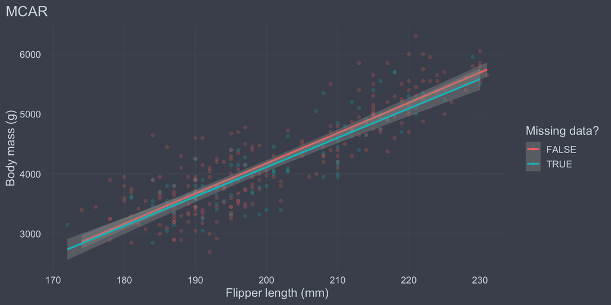

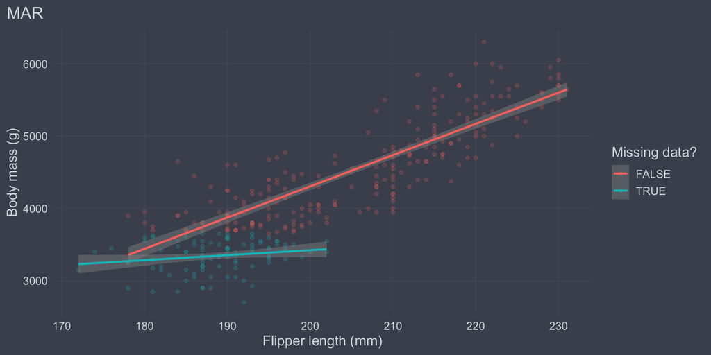

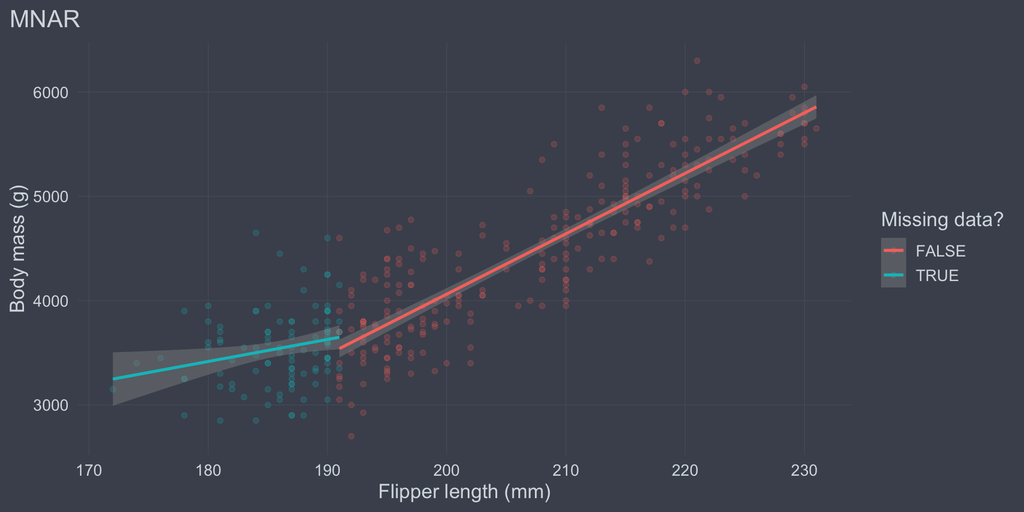

## What can we do about missing data?

With MCAR and MAR we can use multiple imputation techniques

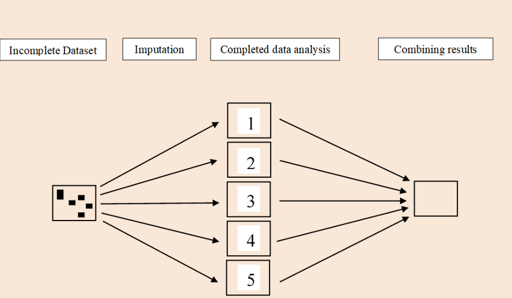

```r
# Load mice
library(mice, quietly = TRUE)

# Set seed for reproducibility
set.seed(123)

# Simulate data: location, year, count
locations <- rep(1:5, each = 5)  # Assuming 5 locations
years <- rep(2009:2023, 5)  # Assuming data for 5 years
count <- round(rpois(25, lambda = 20))  # Simulated count data

# Create a dataframe
data <- data.frame(Location = locations, Year = years, Count = count)

# Introduce missingness - Missing completely at random (MCAR)
prop_missing <- 0.2  # Example: 20% missingness
missing_indices <- sample(1:nrow(data), prop_missing * nrow(data))
data$Count[missing_indices] <- NA

# Check the structure of the data
str(data)
```

```
'data.frame':   75 obs. of  3 variables:
 $ Location: int  1 1 1 1 1 2 2 2 2 2 ...
 $ Year    : int  2009 2010 2011 2012 2013 2014 2015 2016 2017 2018 ...
 $ Count   : num  17 25 12 20 27 NA 14 NA 25 21 ...
```

When we impute the missing data we use 5 replicates and then take the mean of all 5 datasets.

```r
# Impute missing data using MICE
imp <- mice(data, m = 5, method = 'pmm', seed = 500)
```

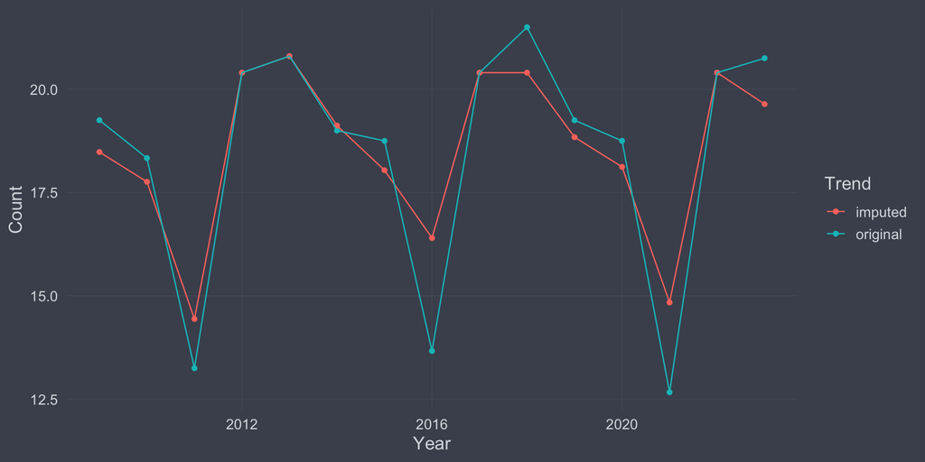

## sem() instead of lm()

Using a Structured Equation Model (SEM) we can run a simple linear regression.

```r
library(lavaan)
# we will use the Iris dataset for this example
complete_model<-lm(Petal.Width ~ Sepal.Length + Sepal.Width + Petal.Length, data=iris)

iris_MCAR<-missMethods::delete_MCAR(iris, 0.3, "Sepal.Width")

miss_model1<-lm(Petal.Width ~ Sepal.Length + Sepal.Width + Petal.Length, data=iris_MCAR)
```

[output not shown]

```r
miss_model2 <- sem('Petal.Width ~ Sepal.Length + Sepal.Width + Petal.Length', data=iris_MCAR, missing="ML")
summary(miss_model2)
```

```
lavaan 0.6-19 ended normally after 1 iteration

  Estimator                                         ML
  Optimization method                           NLMINB
  Number of model parameters                         5

                                                  Used       Total
  Number of observations                           105         150
  Number of missing patterns                         1

Model Test User Model:

  Test statistic                                 0.000
  Degrees of freedom                                 0

Parameter Estimates:

  Standard errors                             Standard
  Information                                 Observed
  Observed information based on                Hessian

Regressions:
                   Estimate  Std.Err  z-value  P(>|z|)
  Petal.Width ~
    Sepal.Length     -0.187    0.056   -3.344    0.001
    Sepal.Width       0.219    0.056    3.945    0.000
    Petal.Length      0.516    0.028   18.133    0.000

Intercepts:
                   Estimate  Std.Err  z-value  P(>|z|)
   .Petal.Width      -0.315    0.211   -1.493    0.135

Variances:
                   Estimate  Std.Err  z-value  P(>|z|)
   .Petal.Width       0.040    0.006    7.246    0.000
```

## Data validation

```r
library(data.validator)
report <- data_validation_report()

between <- function(a, b) {
  function(x) { a <= x & x <= b }
}

validate(iris, name = "Verifying flower dataset") |>
  validate_if(Sepal.Length > 0, description = "Sepal length is greater than 0") |>
  validate_cols(between(0, 4), Sepal.Width, description = "Sepal width is between 0 and 4") |>
  add_results(report)

print(report)
```

```
Validation summary:
 Number of successful validations: 1
 Number of validations with warnings: 0
 Number of failed validations: 1

Advanced view:


|table_name               |description                    |type    | total_violations|
|:------------------------|:------------------------------|:-------|----------------:|
|Verifying flower dataset |Sepal length is greater than 0 |success |               NA|
|Verifying flower dataset |Sepal width is between 0 and 4 |error   |                3|
```

```r
print(report)
```

```
Validation summary:
 Number of successful validations: 1
 Number of validations with warnings: 0
 Number of failed validations: 1

Advanced view:


|table_name               |description                    |type    | total_violations|
|:------------------------|:------------------------------|:-------|----------------:|
|Verifying flower dataset |Sepal length is greater than 0 |success |               NA|
|Verifying flower dataset |Sepal width is between 0 and 4 |error   |                3|
```

## Messy data

Look at the messy data dataset. How would you go about cleaning this dataset?

```r
messy_data <- readRDS(here::here("OS_2024/dataHandling/data/messy_data.RDS"))

messy_data |> data.table::data.table()
```

```
           Date    SEX      age    Species Name       lat      lon count
         <char> <char>   <char>          <char>     <num>    <num> <int>
  1: 2023/02/01   male    Adult    Lagopus matu  9.123826 62.92628     5
  2:   02/02/23 Female Juvenile    Logopus muta  7.836517 61.70676     9
  3: 2023/02/01   male        J    Logopus muta  9.387262 63.84034    15
  4: 01-01-2023 female    ADULT Lagopus lagopus  9.609423 61.06334    14
  5: 01-01-2023   Male    ADULT    Lagopus matu  8.531654 63.44823    10
  6: 2023-02-01   Male        A    Lagopus muta 10.369053 62.60819    10
  7:   02/02/23 FEMALE JUVENILE    Lagopus muta  9.297162 62.71758    11
  8:   02-01-23 FEMALE    Adult Lagopus lagopus  6.479778 61.59151    15
  9: 2023-02-01 female Juvenile    Lagopus muta  7.879991 63.10879     4
 10:   02/02/23   MALE JUVENILE    Lagopus muta  6.794386 62.41039    14
 11: 2023/02/01 Female    ADULT    Lagopus matu 10.075820 62.14845     6
 12:   02-01-23   MALE        J Lagopas lagopus  9.368355 64.29196    13
 13: 2023/02/01 Female    ADULT    Lagopus matu 10.933222 63.08134     8
```

[output cut: 88 more lines]

## Data wrangling

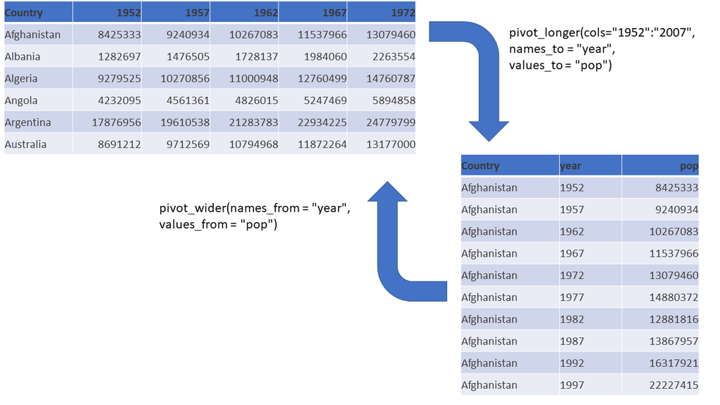

## Transform to long format

```r
library(tidyverse)
# this avoids tidyverse conflicts with the base function filter
conflicted::conflict_prefer("filter", "dplyr")
# Pivot longer
penguins_long<-penguins |>
  pivot_longer(contains("_"),names_to = c("part", "measure" , "unit"),names_sep = "_")

penguins_long
```

```
# A tibble: 1,376 × 8
   species island    sex     year part    measure unit   value
   <fct>   <fct>     <fct>  <int> <chr>   <chr>   <chr>  <dbl>
 1 Adelie  Torgersen male    2007 bill    length  mm      39.1
 2 Adelie  Torgersen male    2007 bill    depth   mm      18.7
 3 Adelie  Torgersen male    2007 flipper length  mm     181
 4 Adelie  Torgersen male    2007 body    mass    g     3750
 5 Adelie  Torgersen female  2007 bill    length  mm      39.5
 6 Adelie  Torgersen female  2007 bill    depth   mm      17.4
 7 Adelie  Torgersen female  2007 flipper length  mm     186
 8 Adelie  Torgersen female  2007 body    mass    g     3800
 9 Adelie  Torgersen female  2007 bill    length  mm      40.3
10 Adelie  Torgersen female  2007 bill    depth   mm      18
# ℹ 1,366 more rows
```

## Transform to wide format

```r
penguins_long |>
  pivot_wider(names_from = species, values_from = value)
```

```
# A tibble: 92 × 9
   island    sex     year part    measure unit  Adelie    Gentoo Chinstrap
   <fct>     <fct>  <int> <chr>   <chr>   <chr> <list>    <list> <list>
 1 Torgersen male    2007 bill    length  mm    <dbl [7]> <NULL> <NULL>
 2 Torgersen male    2007 bill    depth   mm    <dbl [7]> <NULL> <NULL>
 3 Torgersen male    2007 flipper length  mm    <dbl [7]> <NULL> <NULL>
 4 Torgersen male    2007 body    mass    g     <dbl [7]> <NULL> <NULL>
 5 Torgersen female  2007 bill    length  mm    <dbl [8]> <NULL> <NULL>
 6 Torgersen female  2007 bill    depth   mm    <dbl [8]> <NULL> <NULL>
 7 Torgersen female  2007 flipper length  mm    <dbl [8]> <NULL> <NULL>
 8 Torgersen female  2007 body    mass    g     <dbl [8]> <NULL> <NULL>
 9 Torgersen <NA>    2007 bill    length  mm    <dbl [5]> <NULL> <NULL>
10 Torgersen <NA>    2007 bill    depth   mm    <dbl [5]> <NULL> <NULL>
# ℹ 82 more rows
```

## What’s going on?

No identifier for each observation so R puts all the values in a list. To solve this we need a unique row id.

```r
penguins_long |>
  mutate(sample=row_number()) |>
  pivot_wider(names_from = species,values_from = value)
```

```
# A tibble: 1,376 × 10
   island    sex     year part    measure unit  sample Adelie Gentoo Chinstrap
   <fct>     <fct>  <int> <chr>   <chr>   <chr>  <int>  <dbl>  <dbl>     <dbl>
 1 Torgersen male    2007 bill    length  mm         1   39.1     NA        NA
 2 Torgersen male    2007 bill    depth   mm         2   18.7     NA        NA
 3 Torgersen male    2007 flipper length  mm         3  181       NA        NA
 4 Torgersen male    2007 body    mass    g          4 3750       NA        NA
 5 Torgersen female  2007 bill    length  mm         5   39.5     NA        NA
 6 Torgersen female  2007 bill    depth   mm         6   17.4     NA        NA
 7 Torgersen female  2007 flipper length  mm         7  186       NA        NA
 8 Torgersen female  2007 body    mass    g          8 3800       NA        NA
 9 Torgersen female  2007 bill    length  mm         9   40.3     NA        NA
10 Torgersen female  2007 bill    depth   mm        10   18       NA        NA
# ℹ 1,366 more rows
```

## Tidy data


## Tidy data principles

## Untidy data

Have a look at the smallGame dataset.

```r
smallGame <- readRDS(here::here("OS_2024/dataHandling/data/smallGame.RDS"))
```

- What format is it in (long or wide)?
- How would you convert it to the other format?
- Which format do you find easier to use? (there is no “correct” answer to this one!)

## Code style

What are attributes of good code?

Have a look at the “notReproducible.qmd” file

## Tidyverse style guide

[“Good coding style is like correct punctuation: you can manage without it, butitsuremakesthingseasiertoread.”](https://style.tidyverse.org/)

```r
# Examples
day_one # Good
DayOne # Bad
# Avoid names of common functions
T <- FALSE # Bad
c <- 10 # Bad
mean <- function(x) sum(x) # Bad
# Space after a comma
x[, 1] # Good
x[,1] # Bad
# space after () in functions
function(x) {}# Good
function (x) {} # Bad
function(x){} # Bad
```

## Useful packages for style

```r
library(lintr)
# Define the code as a character vector
code <- c(
  "# Spacing ",
  "average<-mean(feet/12 + inches,na.rm=TRUE)",
  "sqrt(x ^ 2 + y ^ 2)",
  "x <- 1 : 10",
  "base :: get",
  "# Indenting",
  "if (y < 0 && debug)",
  "  message('Y is negative')",
  "# Assignment",
  "x = 5"
)

# Write the code to 'bad_style.R'
writeLines(code, "bad_style.R")

# Run lintr on the newly created file
lint("bad_style.R")
```

```
/Users/audhalbritter/Dropbox/Bergen/OS_course/OS-course-teaching-material/OS_2024/dataHandling/bad_style.R:1:10: style: [trailing_whitespace_linter] Trailing whitespace is superfluous.
# Spacing
         ^
/Users/audhalbritter/Dropbox/Bergen/OS_course/OS-course-teaching-material/OS_2024/dataHandling/bad_style.R:2:8: style: [infix_spaces_linter] Put spaces around all infix operators.
average<-mean(feet/12 + inches,na.rm=TRUE)
       ^~
/Users/audhalbritter/Dropbox/Bergen/OS_course/OS-course-teaching-material/OS_2024/dataHandling/bad_style.R:2:19: style: [infix_spaces_linter] Put spaces around all infix operators.
average<-mean(feet/12 + inches,na.rm=TRUE)
                  ^
/Users/audhalbritter/Dropbox/Bergen/OS_course/OS-course-teaching-material/OS_2024/dataHandling/bad_style.R:2:32: style: [commas_linter] Commas should always have a space after.
average<-mean(feet/12 + inches,na.rm=TRUE)
                               ^
/Users/audhalbritter/Dropbox/Bergen/OS_course/OS-course-teaching-material/OS_2024/dataHandling/bad_style.R:2:37: style: [infix_spaces_linter] Put spaces around all infix operators.
average<-mean(feet/12 + inches,na.rm=TRUE)
                                    ^
/Users/audhalbritter/Dropbox/Bergen/OS_course/OS-course-teaching-material/OS_2024/dataHandling/bad_style.R:8:11: style: [quotes_linter] Only use double-quotes.
  message('Y is negative')
          ^~~~~~~~~~~~~~~
/Users/audhalbritter/Dropbox/Bergen/OS_course/OS-course-teaching-material/OS_2024/dataHandling/bad_style.R:10:3: style: [assignment_linter] Use <-, not =, for assignment.
x = 5
  ^
```

```r
library("styler")
style_file("bad_style.R")
```

```
Styling  1  files:
 bad_style.R ℹ
────────────────────────────────────────
Status  Count   Legend
✔   0   File unchanged.
ℹ   1   File changed.
✖   0   Styling threw an error.
────────────────────────────────────────
Please review the changes carefully!
```

```r
readLines("bad_style.R")
```

```
 [1] "# Spacing"
 [2] "average <- mean(feet / 12 + inches, na.rm = TRUE)"
 [3] "sqrt(x^2 + y^2)"
 [4] "x <- 1:10"
 [5] "base::get"
 [6] "# Indenting"
 [7] "if (y < 0 && debug) {"
 [8] "  message(\"Y is negative\")"
 [9] "}"
[10] "# Assignment"
[11] "x <- 5"
```

## What I think…

1. It runs (on your computer)
2. It runs (on my computer - without me having to do anything/much)
3. It does what you expect it to do (even after 5 years)
4. It is documented in some way

## What Jenny Bryan thinks

If the first line of your R script is

```r
setwd("C:\Users\jenny\path\that\only\I\have")
```

I will come into your office and SET YOUR COMPUTER ON FIRE 🔥.

If the first line of your R script is

```r
rm(list = ls())
```

I will come into your office and SET YOUR COMPUTER ON FIRE 🔥.

[figure not shown]